# When things are not normal: Generalized Linear Models

Levi John Wolf

So far in your time at Bristol, you’ve mainly focused on linear models. That is, we’ve mainly focused on models that look like this:
$$y_i = \alpha + x_{1i}\beta_1 + x_{2i}\beta + ... + e_i$$
where we assume that the error $e_i$ is normally-distributed with a mean of zero and a variance that is constant for all the observations. You’ve looked at this model to investigate things like *bias* (when your errors are *not* zero, on average) and heteroskedasticity (when your errors are *not* distributed with a common variance, some observations seem to be noisier than others); you’ve used it to predict many different kinds of things.

# Thinking distributionally

But, let’s stop and think critically about what this represents in terms of *probability*, not *statistics*. A regression model is a kind of *distributional model* that describes how our *expectation* of what value some outcome $y$ will take. This *expectation*, spelled $\mathbf{E}[y]$, is just a guess about what we think $y$ will be.

My single biggest goal in this course is to get you thinking in terms of guesses and predictions… from statistics to [*statistical thinking*](https://doi.org/10.1080/10691898.2002.11910677), this is one of the most difficult parts of stats, [even for statisticians](https://doi.org/10.1080/00031305.2018.1518264)!

## The way you’ve already learned to build guesses

So, clearly, we want to guess well; if the “expected value” is our guess for what $y_i$ will be, what’s our **best** guess for $y_i$? Well… it depends on how we build our guesses. For example, consider the data on waiting times from order to pint at local bars for a student thirsty Thursday event:

| pub | waiting |
| --- | --- |
| The Berkeley | 5.90 |
| The Berkeley | 8.82 |
| The Berkeley | 4.52 |
| The Berkeley | 6.66 |
| The Berkeley | 1.01 |
| The Berkeley | 1.30 |
| The Gallimaufry | 0.63 |
| The Gallimaufry | 3.31 |
| The Gallimaufry | 0.83 |
| The Gallimaufry | 2.23 |
| The Gallimaufry | 0.71 |
| The Gallimaufry | 1.68 |
| The Gallimaufry | 0.41 |
| The Milk Thistle | 15.69 |
| The Milk Thistle | 2.70 |
| The Milk Thistle | 1.86 |
| The Milk Thistle | 4.81 |

Just eyeballing it, about how long do folks wait for a pint?

```r
summary(lm(waiting ~ 1, data=times))
```

```
##
## Call:
## lm(formula = waiting ~ 1, data = times)
##
## Residuals:
##    Min     1Q Median     3Q    Max
## -3.300 -2.704 -1.483  1.103 11.979
##
## Coefficients:
##             Estimate Std. Error t value Pr(>|t|)
## (Intercept)   3.7097     0.9523   3.895  0.00129 **
## ---
## Signif. codes:  0 '***' 0.001 '**' 0.01 '*' 0.05 '.' 0.1 ' ' 1
##
## Residual standard error: 3.926 on 16 degrees of freedom
```

About 4 minutes, or 3.7 minutes to be precise. That means $\mathbf{E}[y] = 3.7$. Further, you can see that the residual standard deviation, the $\sigma$ for $e_i$, is 3.92.. This is because our simple linear model is:
$$waiting_i = 3.7 + e_i$$
which means:
$$\text{waiting}_i \sim \mathcal{N}(3.7, 3.92^2)$$
But, of course: we also know which pub someone waited in. This can give us a *better* prediction:

Check that this is *exactly the same* as the `sd(times$waiting)` if you like

```r
summary(lm(waiting ~ 0 + pub, data=times))
```

```
##
## Call:
## lm(formula = waiting ~ 0 + pub, data = times)
##
## Residuals:
##     Min      1Q  Median      3Q     Max
## -4.4018 -1.4524 -0.5714  1.1966  9.4235
##
## Coefficients:
##                     Estimate Std. Error t value Pr(>|t|)
## pubThe Berkeley        4.700      1.453   3.235  0.00599 **
## pubThe Gallimaufry     1.400      1.345   1.041  0.31550
## pubThe Milk Thistle    6.265      1.780   3.521  0.00339 **
## ---
## Signif. codes:  0 '***' 0.001 '**' 0.01 '*' 0.05 '.' 0.1 ' ' 1
##
## Residual standard error: 3.559 on 14 degrees of freedom
## Multiple R-squared:  0.631,  Adjusted R-squared:  0.552
## F-statistic: 7.981 on 3 and 14 DF,  p-value: 0.002406
```

In *this* model, our best guess for your waiting time is the *average* waiting time in your pub:

```r
times %>% group_by(pub) %>% summarize(mean(waiting))
```

```
## # A tibble: 3 x 2
##   pub              `mean(waiting)`
##   <chr>                      <dbl>
## 1 The Berkeley                4.70
## 2 The Gallimaufry             1.40
## 3 The Milk Thistle            6.27
```

This means $\mathbf{E}[y]$ changes depending on the pub. We could write:
$$y_i|\text{pub you're in} \sim \begin{cases} \text{in Berkeley:} & \text{about 4.7 minutes} \\
\text{in Gallimaufry:} & \text{about 1.4 minutes} \\
\text{in Milk Thistle:} & \text{about 6.25 minutes}
\end{cases}$$
**Our best guess, absent any other information, is just the mean within each group. This is important.** Regression gives you the *expected value* of an outcome given the data you’ve observed. And, since we want some idea of how certain these predictions are, we model how sure we are of this guess using some measure of the *variance* of that expected value. When we know extra information about $y$, we’re modelling the **conditional expectation**, $\mathbf{E}[y | x]$.

Note that $y_i$ **will likely never be normally-distributed by itself** in this example, even though $e_i$ might… The Galli’s average waiting time is quite small and its standard deviation is about the same size. If the waiting time were normal, we’d need to see about half the distribution have a waiting time below 1.4 minutes, and some waiting times **must** be negative!

# Lots of things can have conditional expectation

What if we’re trying to pick a venue for the next thirsty Thursday event, knowing that our impatient friend will only come if he’s going to wait “too long” for a drink. He reveals that he’s recorded whether he felt the wait was too long in a *new* variable:

| waiting | pub | long_wait |
| --- | --- | --- |
| 5.8965696 | The Berkeley | TRUE |
| 8.8221360 | The Berkeley | TRUE |
| 4.5218912 | The Berkeley | TRUE |
| 6.6568445 | The Berkeley | TRUE |
| 1.0058834 | The Berkeley | TRUE |
| 1.2967804 | The Berkeley | FALSE |
| 0.6306975 | The Gallimaufry | TRUE |
| 3.3126954 | The Gallimaufry | TRUE |
| 0.8289619 | The Gallimaufry | FALSE |
| 2.2263338 | The Gallimaufry | TRUE |
| 0.7111698 | The Gallimaufry | FALSE |
| 1.6834961 | The Gallimaufry | TRUE |
| 0.4094267 | The Gallimaufry | TRUE |
| 15.6889250 | The Milk Thistle | TRUE |
| 2.6962470 | The Milk Thistle | FALSE |
| 1.8636174 | The Milk Thistle | FALSE |
| 4.8130465 | The Milk Thistle | TRUE |

```r
sum(times$long_wait)/nrow(times)
```

```
## [1] 0.7058824
```

That is $\mathbf{E}[y]$ when $y$ is binary: the percentage of time that $y=1$. For convenience, let’s call that $\pi$. It just so happens this is *also* the mean of a binary variable:

```r
mean(times$long_wait)
```

```
## [1] 0.7058824
```

which is spooky and also convenient.

and based on the fact that the *expectation* is a fancy version of the weighted average, which both the wikipedia article and Section 2 of the Gelman book will tell you!

But, just eyeballing the table above, it looks like there are some issues. For example, the average wait time is different in different pubs, as we saw before. More to the point, though, is that long waits in The Gallimaufry might be short waits at Milk Thistle: there’s more than just waiting time or pub location, we need both. Absolute length of the wait is only part of the picture. Your friend clearly values the ambiance of a place when deciding whether the wait is short or not, since a long wait at the Gallimaufry is much shorter than a short wait at the Milk Thistle!

like, your friend thought a half-minute wait at the Galley was too long but a 2.5 minute wait at the Milk Thistle was OK. What a demanding patron!

```r
knitr::kable(times %>% group_by(pub, long_wait) %>%
               summarize(n_too_long = n(), mean_wait_time = mean(waiting)))
```

| pub | long_wait | n_too_long | mean_wait_time |
| --- | --- | --- | --- |
| The Berkeley | FALSE | 1 | 1.2967804 |
| The Berkeley | TRUE | 5 | 5.3806650 |
| The Gallimaufry | FALSE | 2 | 0.7700659 |
| The Gallimaufry | TRUE | 5 | 1.6525299 |
| The Milk Thistle | FALSE | 2 | 2.2799322 |
| The Milk Thistle | TRUE | 2 | 10.2509857 |

You could simply try predicting the probability using a linear model to predict whether the wait was long based on the wait time and the pub:

Technically, this model is called a *linear probability model*, since you are using a linear regression to predict probabilities for a binary outcome, but there’s nothing inherently different about the model itself, only $y$.

```r
wait_model2 = lm(long_wait ~ 0 + pub + waiting, data=times)
knitr::kable(broom::tidy(wait_model2))
```

| term | estimate | std.error | statistic | p.value |
| --- | --- | --- | --- | --- |
| pubThe Berkeley | 0.4984616 | 0.2300168 | 2.1670659 | 0.0493913 |
| pubThe Gallimaufry | 0.6145088 | 0.1672170 | 3.6749188 | 0.0028009 |
| pubThe Milk Thistle | 0.0535921 | 0.2926292 | 0.1831399 | 0.8575137 |
| waiting | 0.0712490 | 0.0320067 | 2.2260648 | 0.0443211 |

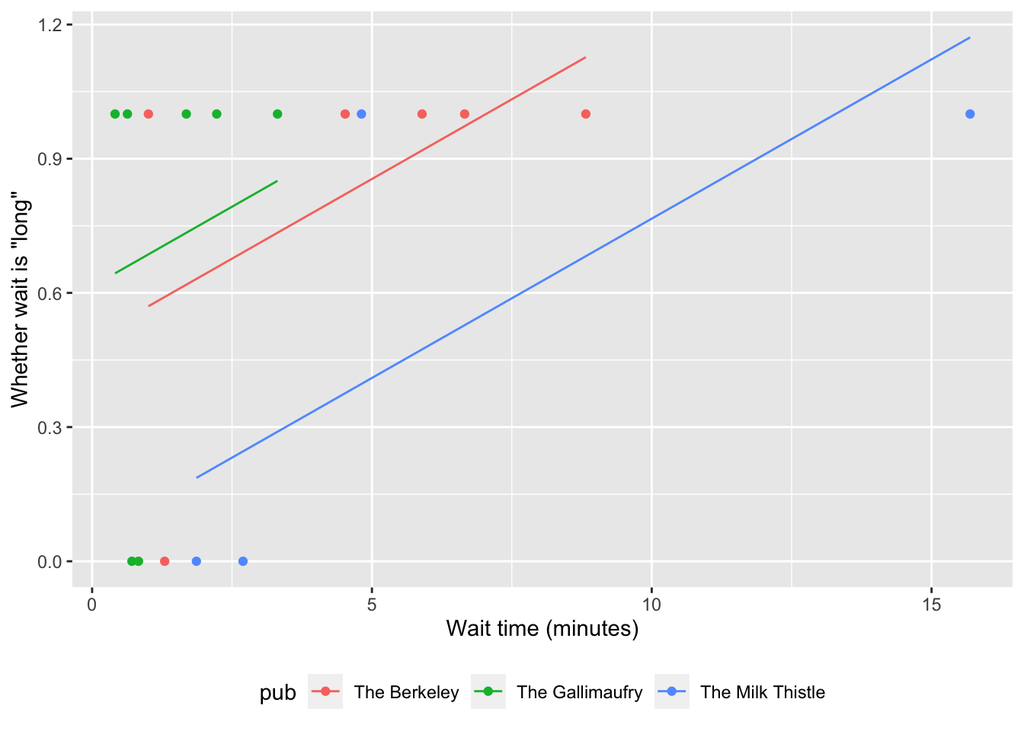

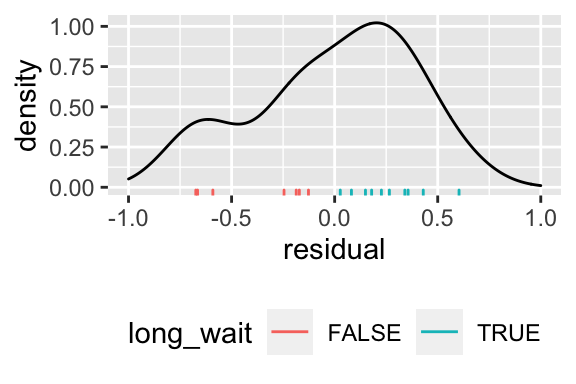

Looking at those lines, you know that the residuals are going to have some odd structure: $y$ can only be zero (if the wait is not too long) or one (if the wait is too long). This means that the residual, usually $y - \hat{y}$, will instead be $0-p_i$ or $1 - p_i$, since $\hat{y}$ in this model is a “predicted probability that $y_i$ is one” ($p_i$), and $y_i$ is only ever zero or one. While it’s possible for these residuals to be distributed normally in abstract, it’s unlikely in practice. This is *not* what we want to see for linear regression, so we have to be *very* careful about interpreting this model.

You can see that the predictions can go a little bit funky… If your friend waits for seven minutes at the Galli, there is a *probability greater than 1* that the wait will be too long:

```r
scenario = data.frame(pub='The Gallimaufry', waiting=7)
predict(wait_model2, scenario)
```

```
##        1
## 1.113252
```

Having a probability over 1 means that there’s more than a 100 percent chance of something happening. That’s [against the law](https://en.wikipedia.org/wiki/Probability_axioms#First_axiom), and I don’t want you to get busted for having contraband probabilities lying around! So, let’s try something a little better than this.

# A generalized linear model

So, to deal with this, we use a **generalized linear model**, or GLM. With a GLM, we still focus on our *conditional expectation* $\mathbf{E}[y|x]$, but it may *not* be the case that our distribution for $y$ is normal. What *is* required is a *link* between what we’re predicting and *some other, latent variable* that actually is normal. So, returning to our expectations, remember that all regression is focused on $\mathbf{E}[y|x]$. But, what is the expected value of a *binary* variable like $y$? Well…

In our linear model predicting long waits, we used a *gaussian* or *normal* model for $\mathbf{E}[y|x]$, but this model was hopeless: the Gaussian model would only give us the *probability* a wait was long (that is, $\pi_i$). So, we *actually* were predicting $\pi_i$ and, since we only observe the $1$ or the $0$, the line of best fit represents our best guess for what those probabilities actually would be.

Another model for $y_i$ that *actually* generates a binary outcome might use the *bernoulli* distribution, which is just the “coin flip” distribution. Instead of the Normal model:
$$y_i \sim \mathcal{N}(\mu, \sigma^2)$$
we use the bernoulli model:
$$y_i \sim \mathcal{Bernoulli}(\pi_i)$$
The Bernoulli distribution still has our nice property from before, where $\mathbf{E}[y_i]=\pi_i$, great. But, we’re still *stuck*: in the Normal model, we knew that we could use $\alpha + X\beta$ to model the mean, $\mu$, since everything was continuous. But, $\pi_i$ is still a *probability*.

So, we transform the probability using the *logit transformation*:
$$logit(y_i) = \log\left(\frac{\pi_i}{1 - \pi_i}\right)$$
Breaking this down, $\frac{\pi_i}{1 - \pi_i}$ is something called the *odds* of $y_i$ happening. You may have heard this before: if a horse has two-to-one (spelled: $2:1$) odds of winning a race, it means that the betters believe that it is 2 times more likely that the horse loses than that they win. A horse that has 15:1 odds is a very unlikely winner[^hence the saying “long odds” meaning that you have some incredibly-long-number to one chance of succeeding.].

Mathematically, odds can vary between zero and infinity: when $\pi_i$ is very small, the odds the odds are very small (well below 1). In our example before, the horse with two-to-one odds has $\pi=.3\bar{3}$, since that value of $\pi$ is the only solution to $\frac{\pi_i}{1-\pi_i} = \frac{1}{2}$. Our horse with 15:1 odds has $\pi = 1/16$, since $\frac{\frac{1}{16}}{1 - \frac{1}{16}} = \frac{1}{15}$. This may seem indirect, but bear with me.

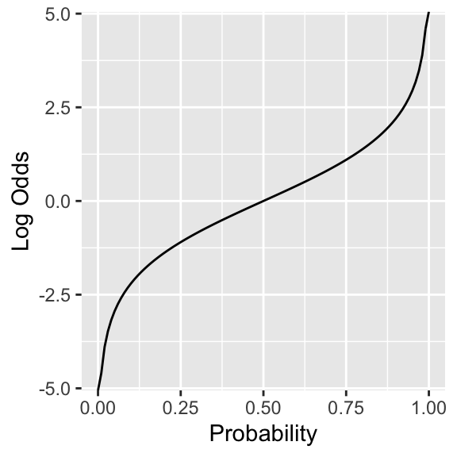

Something very cool happens when we take the *logarithm* of an odds. When $p_i < .5$, the odds are between $0$ and $1$. When $p_i>.5$, the odds are between $1$ and infinity. The *logarithm* of the odds becomes *negative* when $p_i < .5$ and becomes *positive* when $p_i > .5$. This means that you get a kind of “S”-like curve that gets really steep when $p_i$ gets close to its boundary. This “stretches” the log odds space out as $p_i$ gets really small or really large; small changes in $p_i$ in this area create large changes in log odds. This is kind of intuitive: a change from a 100000:1 odds to 1000:1 odds still means the event is still extremely unlikely *and* the change the probability is not that large in absolute terms. But that’s actually a *huge* change in terms of the log odds: they go from $\log(1/100001)=$-11.513 to $\log(1/1001)=$-6.909… almost a halving of the log odds while the *absolute change in probability* change is very small. In sum, this is a pretty good way to model how probabilities work: we want to magnify the changes that represent large *relative* changes, but we don’t want to squash the relative changes that happen in the middle, for things that have around 1:1 odds.

That’s more than the change in log odds when moving from $p_i = .25$ to $p_i = .75$, which is about 2.198!

If we do this, then our model can be stated *just like a linear model*:
$$logit(y_i) = \log\left(\frac{\pi_i}{1 - \pi_i}\right) = \alpha + x_i\beta + e_i$$
This is basically three transformations: from binary to probability, from probability to odds, and then from odds to *log* odds. We run a standard linear regression on the *log odds scale*, and then transform it back to the *probability scale*. The transformation from log odds back to the probability scale is called the *logistic* function, hence why this approach is called *logistic regression*. You can see each step of this process below, moving from our linear model for outcomes on the *log odds* scale (left) to an exponential function in terms of the odds (middle), and then to a *logistic* function in terms of the probabilities (right):

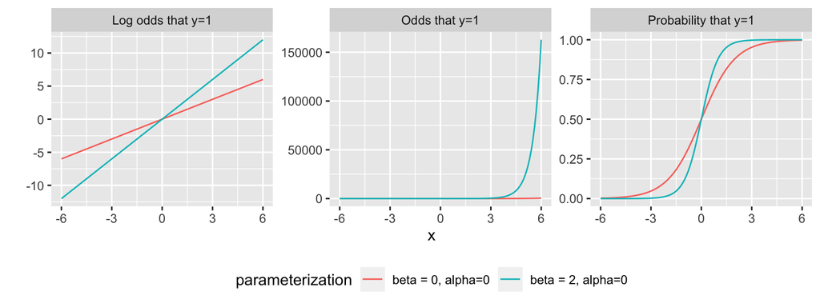

This is nice! as your $\alpha + x_i\beta$ get really small, you get $\pi_i$ that stay around zero! As $\alpha + x_i\beta$ get large, you get probabilities that stay really close to 1! This means that we never get predicted probabilities larger than 1 or smaller than zero like we did with our earlier model.

Fortunately, it’s pretty simple to fit a model like this in R. We can use the `glm()` command and use the exact same formula we did before. However, we need to tell `R` that the `family` of this GLM is `binomial()`, not `gaussian()`, which would simply return the same thing as our original `lm()` command.

```r
wait_model3= glm(long_wait ~ 1 + pub + waiting, data=times, family=binomial())
knitr::kable(broom::tidy(wait_model3))
```

| term | estimate | std.error | statistic | p.value |
| --- | --- | --- | --- | --- |
| (Intercept) | -2.250639 | 2.123210 | -1.0600173 | 0.2891367 |
| pubThe Gallimaufry | 1.134360 | 1.785956 | 0.6351552 | 0.5253272 |
| pubThe Milk Thistle | -5.207691 | 4.236907 | -1.2291256 | 0.2190247 |
| waiting | 1.957421 | 1.353776 | 1.4458977 | 0.1482059 |

Two things might surprise you here:

1. We use `binomial()` in the R command instead of `bernoulli()` because the *binomial* distribution includes the *bernoulli* distribution as a special case. R only provides `binomial()`, since it’s less work to provide both `binomial()` and `bernoulli()`.
2. We’re now fitting an intercept, `1 + pub`, rather than the intercept-less model from above `0 + pub`. The exact reason for this will become clear in the next course block, but for now, notice that (a) the “Berkeley” effect is the `(Intercept)`, and our `pubThe Gallimaufry` effect represents the *difference* between The Berkeley and The Gallimaufry.

   Check the ARM§4.5, pg. 66, *Using discrete rather than continuous predictors* for more info.

Now, we can plot the results in the exact same manner as before, but instead of straight lines, we get these s-shaped *logistic* curves:

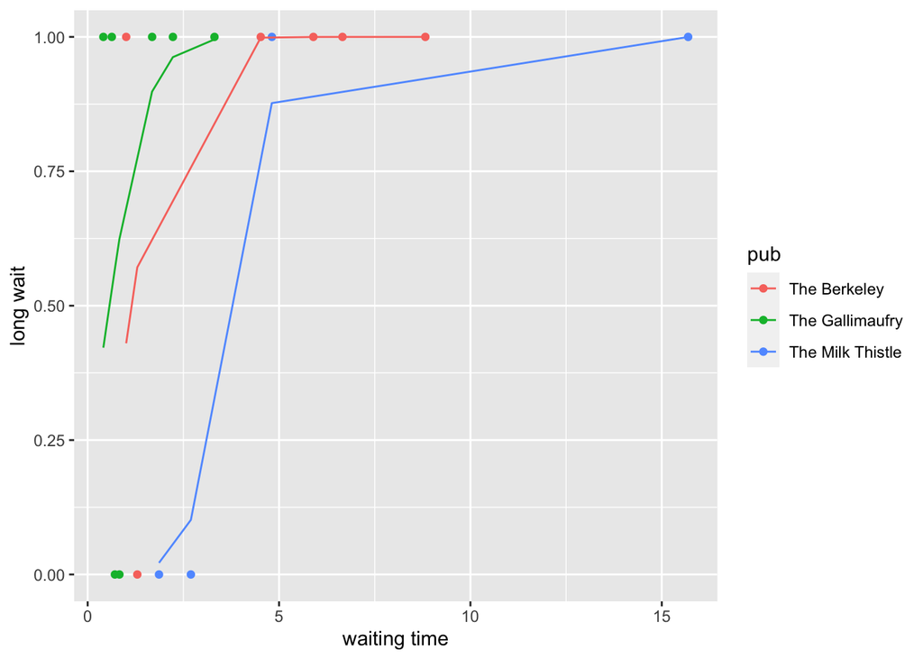

```r
predicted_probabilities = predict(wait_model3, type='response')
ggplot(times, aes(x=waiting, y=as.numeric(long_wait), group=pub, color=pub)) + geom_point() + geom_line(aes(y=predicted_probabilities)) + labs(x='waiting time', y='long wait')
```

Or, smoothing out our plot a little bit more with faked data, we can see the curvature really well

Step through each line on in `R` on your own and take a look at the final `scenario` dataframe to see the result.

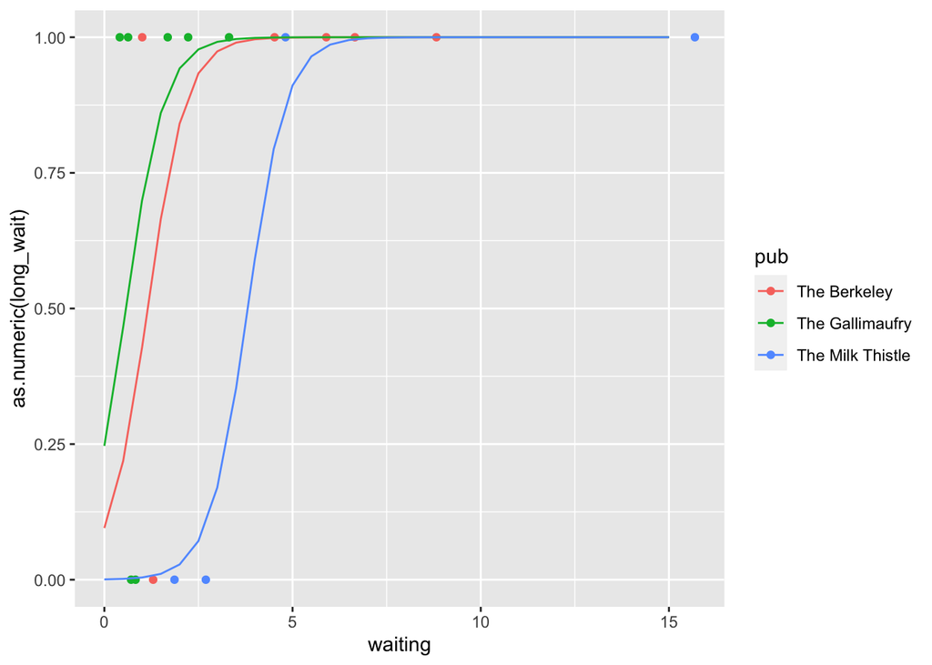

```r
# make fake waiting times from 0 to 15 minutes, every half minute
fake_minutes = seq(0,15,.5)
# get the unique pubs in our data
pubs = unique(times$pub)
# make a scenario dataframe where we:
scenario = data.frame(waiting = rep(fake_minutes, length(pubs)), # 1. repeat the fake_minutes for each pub
                      pub = rep(pubs, each=length(fake_minutes)) # 2. tile the pubs over each set of fake minutes
                        )
scenario['prediction'] = predict(wait_model3, scenario, type='response')
ggplot(times, aes(x=waiting, y=as.numeric(long_wait), color=pub, group=pub)) + geom_point() + geom_line(data=scenario, aes(y=prediction))
```

In this simple model, $\alpha$ controls the location of the curve and $\beta$ controls the speed at which you go from $0$ to $1$. Here, since our model fits *one* $\beta$ for all the pubs (i.e. the effect of an extra minute is the same everywhere) but *different* $\alpha$ for each place (i.e. your friend gives the Milk Thistle a break, but is very harsh on the Gallimaufry), we get three curves that rise at the same rates, but are located on different places.

## Assessing accuracy

Like in the *linear probability model*, the prediction for each observation is a *probability* (or, a log odds) that the observation is a $1$. However, you still get to decide the *threshold* at which you consider a probability high or low. For example, if you say that probabilities higher than $.5$ are considered a “long wait,” then you have to *classify* the observations yourself:

```r
predictions = predicted_probabilities > .5
```

You can see a cross-tabulation of the accuracy of your classification, called a *confusion matrix*, once you build this prediction:

```r
table(predictions, times$long_wait)
```

```
##
## predictions FALSE TRUE
##       FALSE     2    2
##       TRUE      3   10
```

This *confusion matrix* contains the “accurate” predictions on the diagonal and the inaccurate predictions on the off-diagonal. The rows reflect the *predicted* class, and the columns represent the *true* class. The [Wikipedia Article](https://en.wikipedia.org/wiki/Confusion_matrix) provides a very cogent overview of the ways you can summarize this matrix. But, the main kinds of comments we might want to make are things that involve the raw prediction accuracies, and then various kinds of *scores* that describe how effective our classifier is.

For accuracy, we can make a few statements. Five observations were not long waits, and twelve were long waits, while four observations were classified as short waits and thirteen observations were classified as long waits. We can also see that twelve predictions were made correctly, and 5 are incorrect. This means that our classifier’s **accuracy**, or percent of total correct predictions, is 70%. Our *false positive rate* is the percent of all `FALSE` that our model thinks is `TRUE`, which comes to 60%.. All of these are different *views* of how the model is performing.

sums over the columns

sums over rows

sum along the diagonals

twelve correct predictions out of seventeen

*Number of* `TRUE` *predictions in the* `FALSE` *column, divided by the total in the* `FALSE` *column*.

We can *change* this matrix by deciding on a different threshold, too. Let’s look at the confusion matrix when the threshold is $.7$:

```r
table(predicted_probabilities > .7, times$long_wait)
```

```
##
##         FALSE TRUE
##   FALSE     5    3
##   TRUE      0    9
```

If this were, say… a *cancer* screening where `TRUE` meant “has cancer,” we *definitely* want to make sure that everyone who has cancer is correctly predicted as having cancer. So, while it may seem acceptable to improve the accuracy and false positive rate by increasing our threshold, it’s also not always the case that *raw accuracy* is what matters. This is why there are *tons* of different scores that summarize the confusion matrix; they’re each capturing something different about the performance of your classifier *relative to* some objective you care about. Generally, accuracy is fine if classes are roughly the same size and you care about both directions of mis-prediction equally.